# invSCI

### What it does

The identification of domain sets whose outcomes belong to predefined subsets can address fundamental risk assessment challenges in climatology and medicine. A motivating example involves estimating geographical regions where average difference between summer and winter temperatures exceed a certain benchmark, which help policymakers focus on specific areas that are at higher risk for effects of climate change.

Mathematically, the target region correspond to the inverse image of $U \subset \mathbb{R}$ under an unknown function $\mu: \mathcal{S} \to \mathbb{R}$, can be defined as
$$\mu^{-1}(U) = \{s \in S: \mu(s) \in U\}$$
, with $U$ a pre-specified subset of a real line $\mathbb{R}$ (e.g., $[c, \infty)$).

A point estimator for the inverse set can be constructed as $\hat{\mu}_n^{-1}(U)$, where $\hat{\mu}_n$ is an empirical estimator of $\mu$ based on $n$ observations. To quantify the spatial uncertainty of this estimation, Sommerfeld et al. (2018) introduced Coverage Probability Excursion (CoPE) sets, defined as:
$$\text{CS}_{\text{in}}(U) \subseteq \mu^{-1}(U) \subseteq
\text{CS}_{\text{out}}(U)$$
which satisfy:
$$\mathbb{P}\left(\text{CS}_{\text{in}}(U) \subseteq \mu^{-1}(U) \subseteq
\text{CS}_{\text{out}}(U)\right) \geq 1 - \alpha$$
for a pre-specified confidence level $1-\alpha$ (e.g., $\alpha = 0.05$).

Existing approaches require restrictive assumptions, including domain density of $S$ in $R$, continuity of $\hat{\mu}_n$ and $\mu$ near thresholds, and large-sample guarantees, which limit the applicability. Besides, the estimation and coverage depend on setting a fixed threshold level, which is difficult to determine.

Ren et al. (2023) proposed a framework that generalizes the estimation of such inverse sets to dense and non-dense domains with protection against inflated Type I error, and constructs multiple upper, lower or interval confidence sets of $\mu^{-1}(U)$ over arbitrary chosen thresholds. The coverage probability is achieved non-asymptotically and simultaneously through inverting simultaneous confidence intervals. For instance, suppose we are interested in inverse set $\mu^{-1}([c,\infty))$ for a single value $c$, the inverse confidence sets (CSs) are constructed by inverting simultaneous confidence intervals (SCIs). Given SCI bounds $\hat{B}_{l}(\boldsymbol{s})$ and $\hat{B}_{u}(\boldsymbol{s})$ satisfying:

$$\mathbb{P}\left(\forall\boldsymbol{s}\in\mathcal{S}:
\hat{B}_{l}(\boldsymbol{s}) \leq \mu(\boldsymbol{s}) \leq
\hat{B}_{u}(\boldsymbol{s})\right) = 1-\alpha$$

The inner and outer CSs for the inverse upper excursion set
$$\mu^{-1}[c, \infty)$$
are defined as:
$$\text{CS}_{\text{in}}[c, \infty) := \hat{B}_\ell^{-1}[c, \infty)$$

$$\text{CS}_{\text{out}}[c,\infty) := \hat{B}_u^{-1}[c, \infty)$$

The outer and inner confidence sets (CSs) for the inverse lower excursion set $\mu^{-1}\left(-\infty, c\right]$ are defined as:

$$\text{CS}_{\text{in}}\left(-\infty, c\right] :=
\hat{B}_u^{-1}\left(-\infty, c\right]
= \left( \hat{B}_u^{-1}\left[c, +\infty\right) \right)^{\complement}$$

$$\text{CS}_{\text{out}}\left(-\infty, c\right] :=
\hat{B}_\ell^{-1}\left(-\infty, c\right]
= \left( \hat{B}_\ell^{-1}\left[c, +\infty\right) \right)^{\complement}$$

The inner and outer CSs for the inverse interval set $\mu^{-1}[a, b]$ are defined as:

$$\text{CS}_{\text{in}}[a, b] := \hat{B}_\ell^{-1}[a, \infty) \cap
\hat{B}_u^{-1}(-\infty, b]$$

$$\text{CS}_{\text{out}}[a, b] := \hat{B}_u^{-1}[a, \infty) \cap
\hat{B}_\ell^{-1}(-\infty, b]$$

This package provides useful statistical tools for both the estimation of the inverse set and the corresponding simultaneous outer and inner confidence sets (CSs). Acceptable forms of input includes both 1D and 2D data for linear regression, logistic regression, and functional regression. More details can be found below.

### Installation

To install from `CRAN`, please use:

```r
# install.packages("invSCI")
```

To install the latest version directly from Github, please use:

```r
install.packages("devtools")
devtools::install_github("AngelaYuStat/invSCI")
```

### How to use it

The first example here is to use ccds functional data to construct the inverse confidence sets (CS) from simultaneous confidence bands (SCB) using Function-on-Scalar Regression (FoSR).

The ccds dataset contains repeated measures of percent change over time for multiple subjects under two user categories (use: 1 and no use: 0). It includes both user and non-user groups, time points, and metadata related to eye side and frame timing. cleaning process make sure that the data only includes measurements taken from the right eye at the post-intervention timepoint (`tp == "post"`).

```r
library(invSCI)
data(ccds)
```

Before calculating the SCBs, we first process ccds data by fitting a mean GAM model, extracting residuals and performing FPCA using `invSCI::prepare_ccds_fpca()`, the function will return an enhanced dataset includes the FPCA-derived basis scores (Phi1, Phi2, Phi3, Phi4) for Function-on-Scalar Regression (FoSR) analysis.

Following the FPCA-based data augmentation, we fit a FoSR model using `mgcv::bam()`, which allows efficient estimation of Generalized Additive Mixed Models (GAMMs). The model formula is designed to capture both population-level smooth trends and subject-specific functional variation.

```r
ccds_fpca <- invSCI::prepare_ccds_fpca(ccds)
fosr_mod <- mgcv::bam(percent_change ~ s(seconds, k=30, bs="cr") +
            s(seconds, by = use, k=30, bs = "cr") +
            s(subject, by = Phi1, bs="re") +
            s(subject, by = Phi2, bs="re") +
            s(subject, by = Phi3, bs="re") +
            s(subject, by = Phi4, bs="re"),
            method = "fREML", data = ccds_fpca, discrete = TRUE)
```

After obtaining the FoSR object `fosr_mod`, simultaneous confidence bands (SCB) can be constructed though `invSCI::SCB_functional_outcome` using pre-specified methods. The `invSCI` package provides two options for calculating the simultaneous confidence bands (SCB). Use `method` to specify. Use `groups` to specify the names of grouping variables to analyze. The input data should have numerical binary 0/1 values for all scalar group variables. Here, we analyze the user group by specifying `groups = "use"`. Use `fitted` to specify the object for SCB estimation. If `fitted = TRUE`, `invSCI::SCB_functional_outcome` will construct the SCB for the fitted mean outcome function. If `fitted = FALSE`, `invSCI::SCB_functional_outcome` will construct the SCB for the fitted parameter function. Use `est_mean` to specify the point estimate for constructing SCB. If `est_mean = TRUE`, `invSCI::SCB_functional_outcome` will estimate the simultaneous confidence bands for fitted mean outcome function. If `est_mean = FALSE`, `invSCI::SCB_functional_outcome` will estimate the simultaneous confidence bands for sample mean.

```r
# CMA approach
results_ccds_cma <- invSCI::SCB_functional_outcome(data = ccds,
                                          object = fosr_mod,
                                          method = "cma",
                                          fitted = TRUE,
                                          est_mean = TRUE,
                                          alpha = 0.05,
                                          outcome = "percent_change",
                                          time = "seconds",
                                          group_name = "use",
                                          group_value = 1,
                                          subject = "subject")

#CMA approach for parameter function
results_ccds_cma_para <- invSCI::SCB_functional_outcome(data = ccds,
                                          object = fosr_mod,
                                          method = "cma",
                                          fitted = FALSE,
                                          est_mean = TRUE,
                                          alpha = 0.05,
                                          outcome = "percent_change",
                                          time = "seconds",
                                          group_name = "use",
                                          group_value = 1,
                                          subject = "subject")

# Multiplier-t Bootstrap
results_ccds_wild <- invSCI::SCB_functional_outcome(data = ccds,
                                          object = fosr_mod,
                                          method = "wild",
                                          fitted = TRUE,
                                          est_mean = TRUE,
                                          alpha = 0.05,
                                          outcome = "percent_change",
                                          time = "seconds",
                                          group_name = "use",
                                          group_value = 1,
                                          subject = "subject")

# Multiplier-t Bootstrap (use sample mean)
results_ccds_wild_sample <- invSCI::SCB_functional_outcome(data = ccds,
                                          object = fosr_mod,
                                          method = "wild",
                                          fitted = TRUE,
                                          est_mean = FALSE,
                                          alpha = 0.05,
                                          outcome = "percent_change",
                                          time = "seconds",
                                          group_name = "use",
                                          group_value = 1,
                                          subject = "subject")
```

The followings are the mathematical details:

#### Correlation and Multiplicity Adjusted (CMA) Confidence Bands Based on Parameter Simulations

1. Simulate model parameters $\boldsymbol{\beta}_1, \ldots, \boldsymbol{\beta}_B \overset{\text{i.i.d.}}{\sim} \mathcal{N}(\hat{\boldsymbol{\beta}}, \hat{V}_{\boldsymbol{\beta}})$ , where $(\hat{\boldsymbol{\beta}}, \hat{V}_{\boldsymbol{\beta}})$ are estimated via a fitted FoSR model.
2. For each $b = 1, \ldots, B$, compute
   $$\mathbf{X}_b = \frac{\mathbf{B}({\beta}_b -
   \hat{{\beta}})}{\mathbf{D}_f}$$
   , where the division is element-wise and $\mathbf{B}$ maps parameters to functional effects.
3. Let
   $$d_b = \max(|\mathbf{X}_b|), \quad b = 1, \ldots, B$$
   , where the absolute value is taken element-wise.
4. Estimate $q(C_f, 1 - \alpha)$ as the $100 \cdot (1 - \alpha)$ percentile of $\{d_1, \ldots, d_B\}$.

#### Multiplier-t Bootstrap Procedure for Constructing Confidence Bands

1. Compute residuals $R_1^N, \ldots, R_N^N$, where $R_n^N = \sqrt{\frac{N}{N - 1}} \left( Y_n - \hat{\mu}_N \right)$, and multipliers $g_1, \ldots, g_N \overset{\text{i.i.d.}}{\sim} g$ with $\mathbb{E}[g] = 0$ and $\mathrm{var}[g] = 1$.
2. Estimate $\hat{\epsilon}_N^*(s)$ from $g_1 Y_1(s), \ldots, g_N Y_N(s)$.
3. Compute
   $$T^*(s) = \frac{1}{\sqrt{N}} \sum_{n=1}^N g_n
   \frac{R_n^N(s)}{\hat{\epsilon}_N^*(s)}$$
4. Repeat steps 1 to 3 many times. Take the $(1 - \alpha) \cdot 100\%$ quantile of $\mathcal{L}^*$ to estimate $q_{\alpha, N}$.

For details of the algorithm, please refer to Telschow et al. (2019)

`invSCI` provides two options for estimating the mean function at $s$, denoted as $\hat{\mu}_N(s)$. If `est_mean = TRUE`, the mean function will be estimated though using the fitted regression object. If `est_mean = FALSE`, sample mean will be calculated. Default is `FALSE`.

1. The **sample mean**
   $$\hat{\mu}_N(s) = \frac{1}{N} \sum_{i=1}^N {Y}_i(s)$$
   , where ${Y}_i(s)$ is the observed functional response.
2. The **fitted mean value** from a functional regression model (e.g., using `mgcv::bam`).

In the wild bootstrap procedure, `invSCI` supports three types of multiplier distributions, which is specified by `weights`:

- `"rademacher"`: $g_i \in \{-1, +1\}$ with equal probability
- `"gaussian"`: $g_i \sim \mathcal{N}(0, 1)$
- `"mammen"`: A two-point distribution with mean zero and variance one (see Mammen, 1993)

Default is `rademacher`.

Two options are available for estimating the standard error $\hat{\epsilon}_N^*(s_j)$, which is specified by `method_SD`:

- “regular” (empirical standard error based on residuals):
  $$\hat{\epsilon}_N^*(s_j) = \sqrt{ \frac{1}{n} \sum_{i=1}^n \left(
  {Y}_i(s_j) - \hat{\beta}(s_j) \right)^2 / (n-1) }$$
  .
- “t” (bootstrap second moment-based estimator):
  $$\hat{\epsilon}_N^*(s_j) = \sqrt{ \frac{N}{N-1} \left| \mathbb{E}_b\left[
  {Y}^{b}(s_j)^2 \right] - \left( \mathbb{E}_b\left[ {Y}^{b}(s_j) \right]
  \right)^2 \right| }$$
  , where expectations are taken over bootstrap replicates and ${Y}^{b}(s_j)$ is the perturbed sample in bootstrap iteration $b$. The absolute value ensures numerical stability when subtracting large, nearly equal quantities.

Default is `t`.

The code below visualizes the **inverse confidence sets (CSs)** derived from SCB results using the `invSCI::plot_cs()` function. The `results` object is first converted to a tibble for easier manipulation.

The `levels = c(-7, -8, -9, -10)` argument specifies a set of thresholds, and `invSCI::plot_cs()` function estimates multiple inverse upper excursion sets corresponding to these thresholds, and plot the estimated inverse set, the inner confidence set, and the outer confidence set.

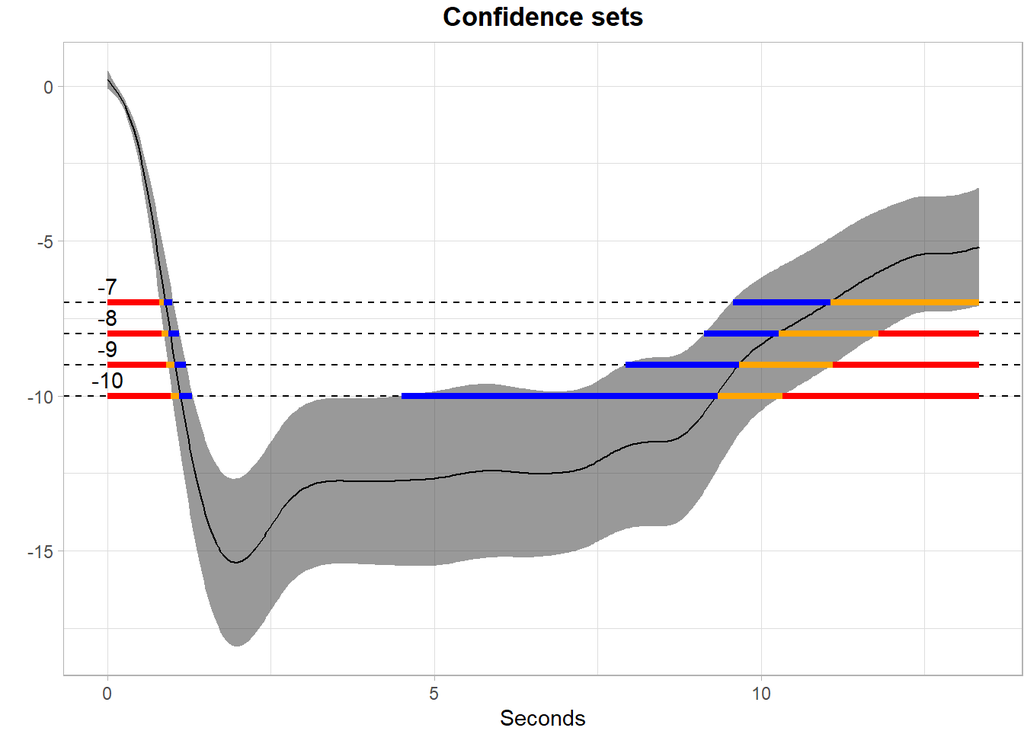

```r
results_ccds_cma <- tibble::as_tibble(results_ccds_cma)
plot_cs(results_ccds_cma,
        levels = c(-7, -8, -9, -10),
        x = results_ccds_cma$time,
        mu_hat = results_ccds_cma$yhat,
        xlab = "Seconds",
        ylab = "Percent_Outcome",
        level_label = T,
        min.size = 40,
        palette = "Spectral",
        color_level_label = "black")
```

The plot demonstrate how to use SCB to find regions of s where the estimated mean is greater than or equal to the four levels -7, -8, -9, -10 for ccds data. The gray shaded area is the 95% SCB, the solid black line is the estimated mean. The red horizontal line shows the inner confidence sets (where the lower SCB is greater than the corresponding level) that are contained in the estimated inverse set represented by the union of the yellow and red horizontal line (where the estimated mean is greater than the corresponding levels); the outer confidence sets are the union of the blue, yellow and red line (where the upper SCB is greater than the corresponding levels) and contain both the estimated inverse sets and the inner confidence sets.

The next plot shows the SCB for the coefficient funtion for the use group.

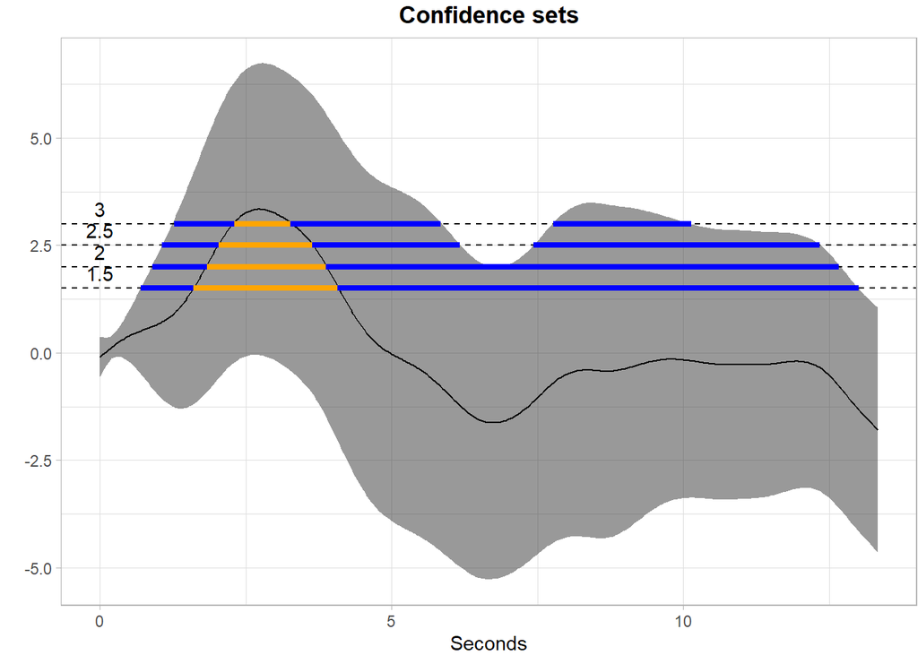

```r
results_ccds_cma_para <- tibble::as_tibble(results_ccds_cma_para)
plot_cs(results_ccds_cma_para,
        levels = c( c(1.5, 2, 2.5, 3)),
        x = results_ccds_cma_para$time,
        mu_hat = results_ccds_cma_para$yhat,
        xlab = "Seconds",
        ylab = "Percent_Outcome",
        level_label = T,
        min.size = 40,
        palette = "Spectral",
        color_level_label = "black")
```

The following plots show the results of wild bootstrap. The only difference between these two plots is that, the solid black line in the first one represents the estimated mean fitted through functional regresson object, while the second represents the sample mean. All possible NA’s are imputed using `refund::fpca.face()`.

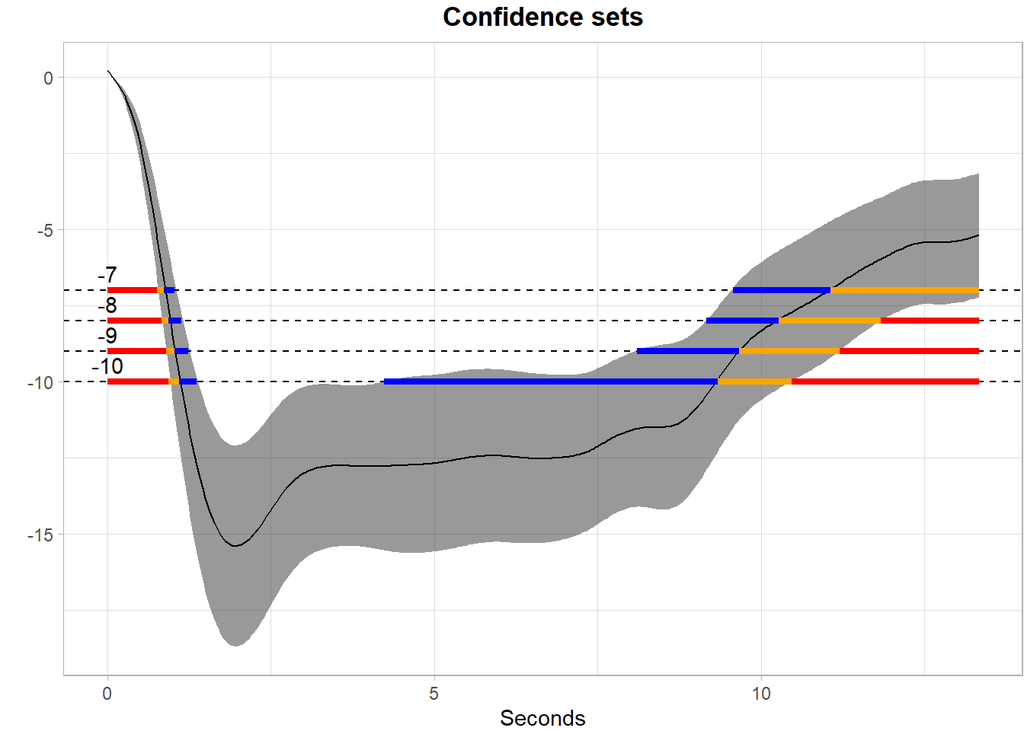

```r
results_ccds_wild <- tibble::as_tibble(results_ccds_wild)
plot_cs(results_ccds_wild,
        levels = c(-7, -8, -9, -10),
        x = results_ccds_wild$time,
        mu_hat = results_ccds_wild$yhat,
        xlab = "Seconds",
        ylab = "Percent_Outcome",
        level_label = T,
        min.size = 40,
        palette = "Spectral",
        color_level_label = "black")
```

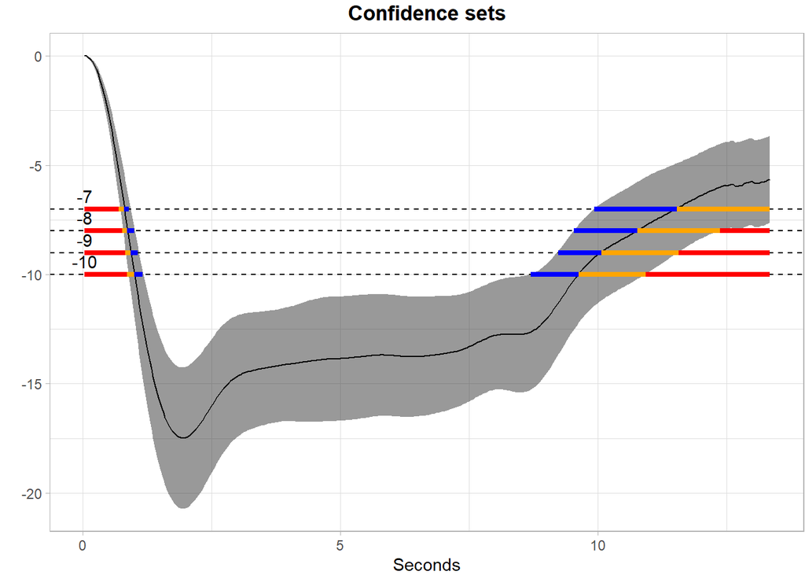

```r
results_ccds_wild_sample <- tibble::as_tibble(results_ccds_wild_sample)
plot_cs(results_ccds_wild_sample,
        levels = c(-7, -8, -9, -10),
        x = results_ccds_wild_sample$time,
        mu_hat = results_ccds_wild_sample$yhat,
        xlab = "Seconds",
        ylab = "Percent_Outcome",
        level_label = T,
        min.size = 40,
        palette = "Spectral",
        color_level_label = "black")
```

To further illustrate the power of `invSCI::SCB_functional_outcome` for constructing SCBs for multiple group variables, we load the pupil data and perform the analysis introduced before.

```r
data(pupil)
library(dplyr)
# filter all NA subjects
pupil_fpca <- invSCI::prepare_pupil_fpca(pupil)
fosr_mod <- mgcv::bam(percent_change ~ s(seconds, k=30, bs="cr") +
            s(seconds, by = use, k=30, bs = "cr") +
            s(seconds, by = age, k = 30, bs = "cr") +
            s(seconds, by = gender, k=30, bs = "cr") +
            s(id, by = Phi1, bs="re") +
            s(id, by = Phi2, bs="re") +
            s(id, by = Phi3, bs="re") +
            s(id, by = Phi4, bs="re"),
            method = "fREML", data = pupil_fpca, discrete = TRUE)
```

Here, we analyze the daily male user group by specifying `group_name = c("use", "age", "gender")` and `group_value = c(1, 40, 0)`. We set `fitted = TRUE` and `est_mean= TRUE`.

```r
# CMA approach
results_pupil_cma <- invSCI::SCB_functional_outcome(data = pupil,
                                          object = fosr_mod,
                                          method = "cma",
                                          fitted = TRUE,
                                          est_mean = TRUE,
                                          alpha = 0.05,
                                          outcome = "percent_change",
                                          time = "seconds",
                                          group_name = c("use", "age", "gender"),
                                          group_value = c(1, 40, 0),
                                          subject = "id")

# Multiplier-t Bootstrap
results_pupil_wild <- invSCI::SCB_functional_outcome(data = pupil,
                                          object = fosr_mod,
                                          fitted = TRUE,
                                          method = "wild",
                                          est_mean = TRUE,
                                          alpha = 0.05,
                                          outcome = "percent_change",
                                          time = "seconds",
                                          group_name = c("use", "age", "gender"),
                                          group_value = c(1, 40, 0),
                                          subject = "id")
```

The following plots show the SCBs and inverse SCBs for the mean outcome function. The first one is from CMA approach and the second is from wild bootstrap.

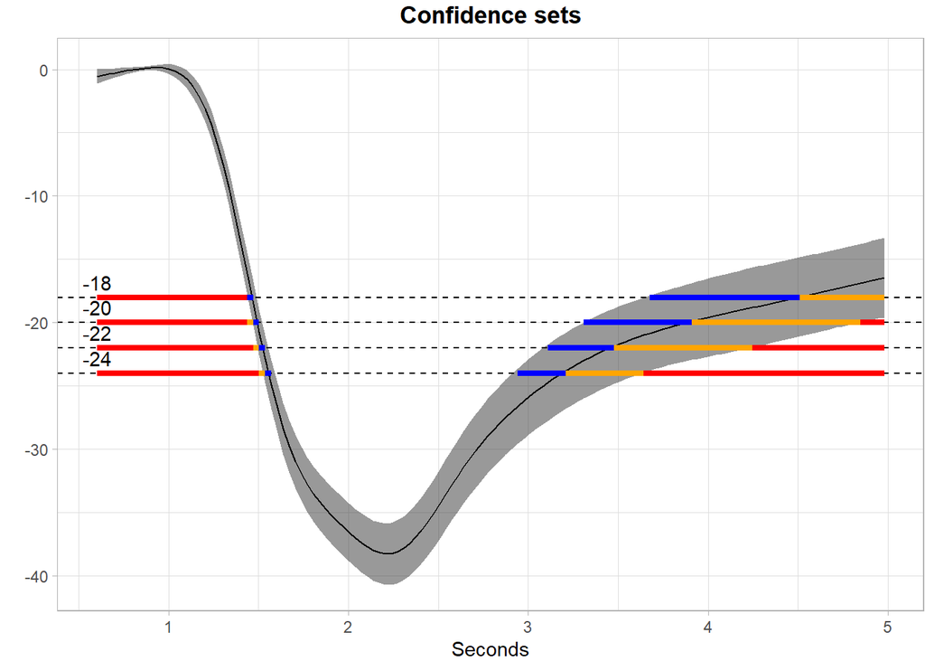

```r
results_pupil_cma <- tibble::as_tibble(results_pupil_cma)
plot_cs(results_pupil_cma,
        levels = c(-18, -20, -22, -24),
        x = results_pupil_cma$time,
        mu_hat = results_pupil_cma$yhat,
        xlab = "Seconds",
        ylab = "Percent_Outcome",
        level_label = T,
        min.size = 40,
        palette = "Spectral",
        color_level_label = "black")
```

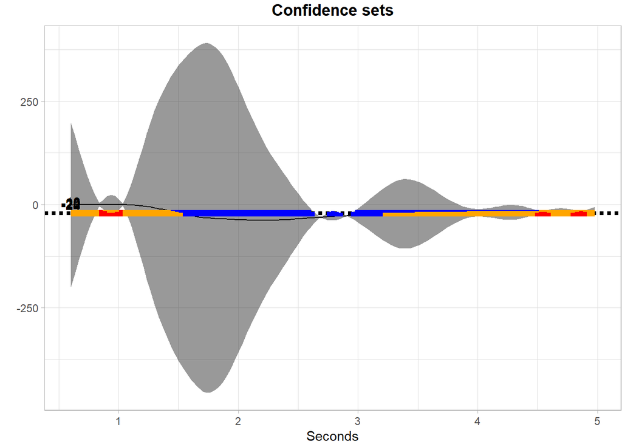

```r
results_pupil_wild <- tibble::as_tibble(results_pupil_wild)
plot_cs(results_pupil_wild,
        levels = c(-18, -20, -22, -24),
        x = results_pupil_wild$time,
        mu_hat = results_pupil_wild$yhat,
        xlab = "Seconds",
        ylab = "Percent_Outcome",
        level_label = T,
        min.size = 40,
        palette = "Spectral",
        color_level_label = "black")
```

The second example here is to use simulated data to construct the inverse confidence sets (CS) from simultaneous confidence bands (SCB) using linear regression.

`invSCI::SCB_linear_outcome()` function use a non-parametric bootstrap algorithm to construct the SCB in linear regression. The argument `df_fit` specifies a data frame containing the training design matrix used to fit the linear model, while `grid_df` contains the test set design matrix for constructing SCB. Use argument `model` to specify the formula used for fitting the linear model.

```r
library(invSCI)
set.seed(262)
# generate simulated data
x1 <- rnorm(100)
x2 <- rnorm(100)
epsilon <- rnorm(100,0,sqrt(2))
y <- -1 + x1 + 0.5 * x1^2 - 1.1 * x1^3 - 0.5 * x2 + 0.8 * x2^2 - 1.1 * x2^3 + epsilon
df <- data.frame(x1 = x1, x2 = x2, y = y)
grid <- data.frame(x1 = seq(-1, 1, length.out = 100), x2 = seq(-1, 1, length.out = 100))
# fit the linear regression model and obtain the SCB for y
model <- "y ~ x1 + I(x1^2) + I(x1^3) + x2 + I(x2^2) + I(x2^3)"
results <- SCB_linear_outcome(df_fit = df, model = model, grid_df = grid)
```

Likewise, the `levels = c(-0.3, 0, 0.3)` argument specifies a set of thresholds, and `invSCI::plot_cs()` function estimates multiple inverse upper excursion sets corresponding to these thresholds, and plot the estimated inverse set, the inner confidence set, and the outer confidence set.

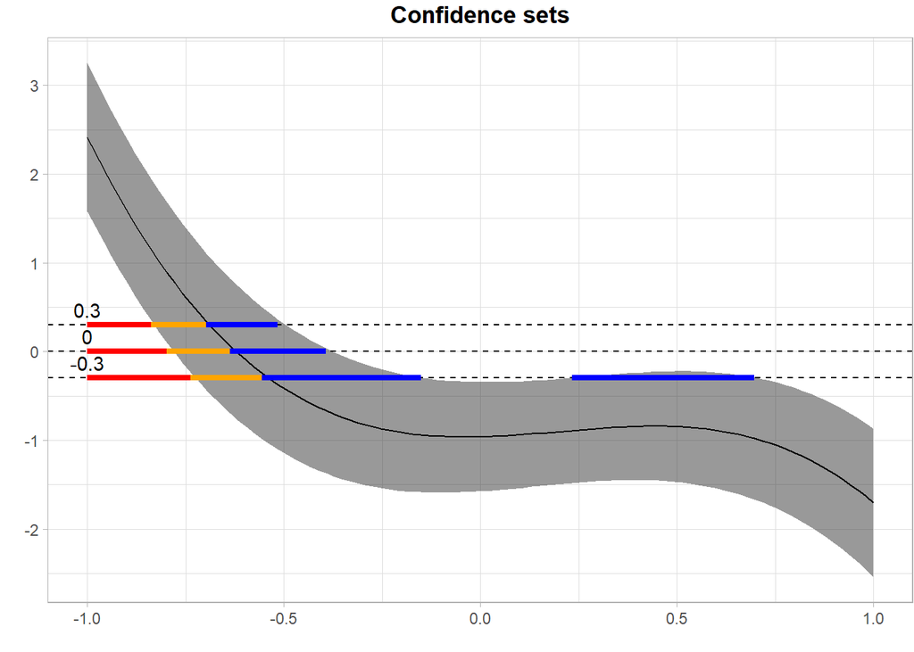

```r
results <- tibble::as_tibble(results)
plot_cs(results,
        levels = c(-0.3, 0, 0.3),
        x = seq(-1, 1, length.out = 100),
        mu_hat = results$Mean,
        xlab = "",
        ylab = "",
        level_label = T,
        min.size = 40,
        palette = "Spectral",
        color_level_label = "black")
```

In addition to linear regression, `invSCI` also provides`invSCI::SCB_logistic_outcome()` for estimating the SCB for outcome of logistic regression, and `invSCI::SCB_regression_coef`can estimate the SCB for every coefficient in the linear/logistic model. For details, please refer to the corresponding package vignette.